# Medical Cost: EDA and Regression

[figure not shown]

Created: 2020-09-01

Last updated: 2020-09-01

Kaggle Kernel made by 🚀 [Rafael Morais de Assis](https://www.kaggle.com/rafanthx13)

In Progress

**Some References**

- https://www.kaggle.com/hely333/eda-regression
- https://www.kaggle.com/janiobachmann/patient-charges-clustering-and-regression
- https://www.kaggle.com/mariapushkareva/medical-insurance-cost-with-linear-regression

## Problem Description

[Kaggle Link DataSet](https://www.kaggle.com/mirichoi0218/insurance)

**Context**

DataSet with the cost of treatment of different patients of US. Of course, there are several factors that influence the price of treatment but in this dataset has: age, bmi, sex, number of children / dependents, region of US, has children or not and finally the cost of treatment.

**File Description**

`insurance.csv`: DataSet with 1,338 rows and 7 columns

## DataSet Description

| Column | Description | Values |
| --- | --- | --- |
| age | age of primary beneficiary | int :: [18, 64] |
| sex | insurance contractor gender, female, male | string :: ['female','male'] |
| bmi | Body mass index, providing an understanding of body, weights that are relatively high or low relative to height, objective index of body weight (kg / m ^ 2) using the ratio of height to weight, ideall… | number :: [15.960, 53.130] |
| children | Number of children covered by health insurance. Number of dependents | number :: [0,5] |
| smoker | Smoking or Not | string :: ['yes','no'] |
| region | the beneficiary's residential area in the US | string :: [northeast, southeast, southwest, northwest] |
| charges | Individual medical costs billed by health insurance | number :: [1,121.878 , 63,770.428] |

## The Goal

Based on the features predict the cost for a patient

## Import Libs and DataSet Go to TOC

```python
import numpy as np
import pandas as pd
import matplotlib.pyplot as plt
import seaborn as sns

import warnings
import time
warnings.filterwarnings("ignore")

import os
for dirname, _, filenames in os.walk('/kaggle/input'):
    for filename in filenames:
        print(os.path.join(dirname, filename))

# Configs
pd.options.display.float_format = '{:,.3f}'.format
sns.set(style="whitegrid")
plt.style.use('seaborn')
seed = 42
np.random.seed(seed)
```

```
/kaggle/input/insurance/insurance.csv
```

```python
file_path = '/kaggle/input/insurance/insurance.csv'
df = pd.read_csv(file_path)

print("Test DataSet = {} rows and {} columns\n".format(
    df.shape[0], df.shape[1]))

quantitative = [f for f in df.columns if df.dtypes[f] != 'object']
qualitative  = [f for f in df.columns if df.dtypes[f] == 'object']

print("Qualitative Variables: (Numerics)", "\n=>", qualitative,
      "\n\nQuantitative Variable: (Strings)\n=>", quantitative)

df.head()
```

```
Test DataSet = 1338 rows and 7 columns

Qualitative Variables: (Numerics)
=> ['sex', 'smoker', 'region']

Quantitative Variable: (Strings)
=> ['age', 'bmi', 'children', 'charges']
```

|  | age | sex | bmi | children | smoker | region | charges |
| --- | --- | --- | --- | --- | --- | --- | --- |
| 0 | 19 | female | 27.900 | 0 | yes | southwest | 16,884.924 |
| 1 | 18 | male | 33.770 | 1 | no | southeast | 1,725.552 |
| 2 | 28 | male | 33.000 | 3 | no | southeast | 4,449.462 |
| 3 | 33 | male | 22.705 | 0 | no | northwest | 21,984.471 |
| 4 | 32 | male | 28.880 | 0 | no | northwest | 3,866.855 |

## Snippets Go to TOC

```python
def eda_categ_feat_desc_plot(series_categorical, title = ""):
    """Generate 2 plots: barplot with quantity and pieplot with percentage.
       @series_categorical: categorical series
       @title: optional
    """
    series_name = series_categorical.name
    val_counts = series_categorical.value_counts()
    val_counts.name = 'quantity'
    val_percentage = series_categorical.value_counts(normalize=True)
    val_percentage.name = "percentage"
    val_concat = pd.concat([val_counts, val_percentage], axis = 1)
    val_concat.reset_index(level=0, inplace=True)
    val_concat = val_concat.rename( columns = {'index': series_name} )

    fig, ax = plt.subplots(figsize = (12,4), ncols=2, nrows=1) # figsize = (width, height)
    if(title != ""):
        fig.suptitle(title, fontsize=18)
        fig.subplots_adjust(top=0.8)

    s = sns.barplot(x=series_name, y='quantity', data=val_concat, ax=ax[0])
    for index, row in val_concat.iterrows():
        s.text(row.name, row['quantity'], row['quantity'], color='black', ha="center")

    s2 = val_concat.plot.pie(y='percentage', autopct=lambda value: '{:.2f}%'.format(value),
                             labels=val_concat[series_name].tolist(), legend=None, ax=ax[1],
                             title="Percentage Plot")

    ax[1].set_ylabel('')
    ax[0].set_title('Quantity Plot')

    plt.show()
```

```python
def eda_numerical_feat(series, title="", number_format="", with_label=True):
    f, (ax1, ax2) = plt.subplots(ncols=2, figsize=(15, 4), sharex=False)
    if(title != ""):
        f.suptitle(title, fontsize=18)
    sns.distplot(series, ax=ax1, rug=True)
    sns.boxplot(series, ax=ax2)
    ax1.set_title("distplot")
    ax2.set_title("boxplot")
    if(with_label):
        describe = series.describe()
        labels = { 'min': describe.loc['min'], 'max': describe.loc['max'],
              'Q1': describe.loc['25%'], 'Q2': describe.loc['50%'],
              'Q3': describe.loc['75%']}
        if(number_format != ""):
            for k, v in labels.items():
                ax2.text(v, 0.3, k + "\n" + number_format.format(v), ha='center', va='center', fontweight='bold',
                         size=10, color='white', bbox=dict(facecolor='#445A64'))
        else:
            for k, v in labels.items():
                ax2.text(v, 0.3, k + "\n" + str(v), ha='center', va='center', fontweight='bold',
                     size=10, color='white', bbox=dict(facecolor='#445A64'))
    plt.show()
```

```python
def plot_model_score_regression(models_name_list, model_score_list, title=''):
    fig = plt.figure(figsize=(15, 6))
    ax = sns.pointplot( x = models_name_list, y = model_score_list,
        markers=['o'], linestyles=['-'])
    for i, score in enumerate(model_score_list):
        ax.text(i, score + 0.002, '{:.4f}'.format(score),
                horizontalalignment='left', size='large',
                color='black', weight='semibold')
    plt.ylabel('Score', size=20, labelpad=12)
    plt.xlabel('Model', size=20, labelpad=12)
    plt.tick_params(axis='x', labelsize=12)
    plt.tick_params(axis='y', labelsize=12)
    plt.xticks(rotation=70)
    plt.title(title, size=20)
    plt.show()
```

## Missing data Go to TOC

Has no missing data

```python
df.isnull().sum()
```

```
age         0
sex         0
bmi         0
children    0
smoker      0
region      0
charges     0
dtype: int64
```

## EDA

### Each feature individually Go to TOC

```python
df.columns
```

```
Index(['age', 'sex', 'bmi', 'children', 'smoker', 'region', 'charges'], dtype='object')
```

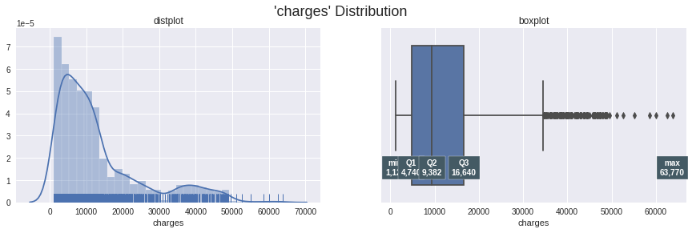

```python
eda_numerical_feat(df['charges'], "'charges' Distribution", "{:,.0f}")
```

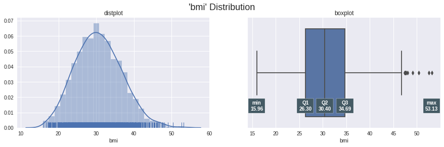

```python
eda_numerical_feat(df['bmi'], "'bmi' Distribution", "{:.2f}")
```

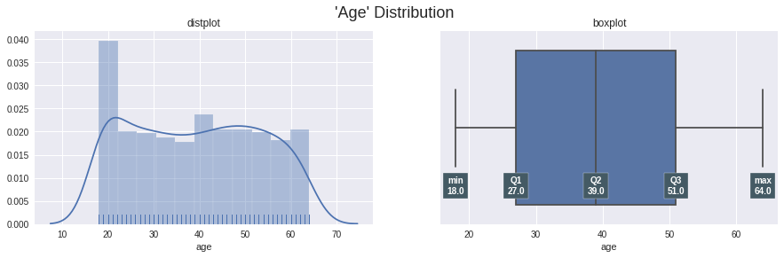

```python
eda_numerical_feat(df['age'], "'Age' Distribution")
```

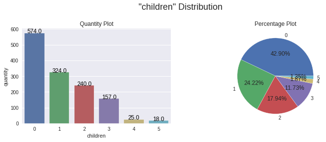

```python
eda_categ_feat_desc_plot(df['children'], '"children" Distribution')
```

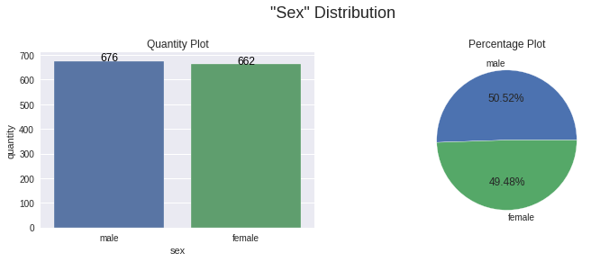

```python
eda_categ_feat_desc_plot(df['sex'], '"Sex" Distribution')
```

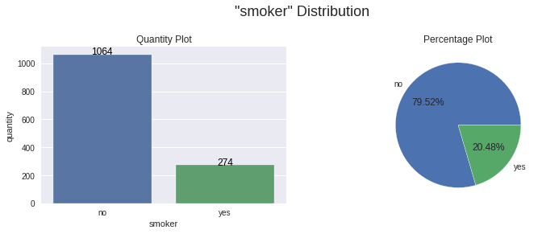

```python
eda_categ_feat_desc_plot(df['smoker'], '"smoker" Distribution')
```

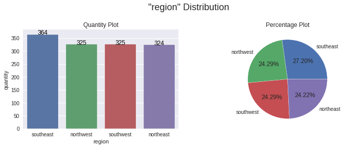

```python
eda_categ_feat_desc_plot(df['region'], '"region" Distribution')
```

### Each feauture with 'charges' Go to TOC

[figure not shown]

```python
fig, ((ax1, ax2), (ax3,ax4), (ax5, ax6)) = plt.subplots(figsize = (16,14), ncols=2, nrows=3, sharex=False, sharey=False)

# sex
sns.boxplot(x="sex", y="charges", data=df, ax=ax1)
sns.distplot(df[ df['sex'] == 'male']['charges'], ax=ax2, hist=False, label="male")
sns.distplot(df[ df['sex'] == 'female']['charges'], ax=ax2, hist=False, label="female")
# region
sns.boxplot(x="region", y="charges", data=df, ax=ax3)
sns.kdeplot(df[ df['region'] == 'southwest']['charges'], ax=ax4, label="southwest")
sns.kdeplot(df[ df['region'] == 'southeast']['charges'], ax=ax4, label="southeast")
sns.kdeplot(df[ df['region'] == 'northwest']['charges'], ax=ax4, label="northwest")
sns.kdeplot(df[ df['region'] == 'northeast']['charges'], ax=ax4, label="northeast")
# children
sns.boxplot(x="children", y="charges", data=df, ax=ax5)
sns.distplot(df[ df['children'] == 0]['charges'], ax=ax6, hist=False, label="0")
sns.distplot(df[ df['children'] == 1]['charges'], ax=ax6, hist=False, label="1")
sns.distplot(df[ df['children'] == 2]['charges'], ax=ax6, hist=False, label="2")
sns.distplot(df[ df['children'] == 3]['charges'], ax=ax6, hist=False, label="3")
sns.distplot(df[ df['children'] == 4]['charges'], ax=ax6, hist=False, label="4")
sns.distplot(df[ df['children'] == 5]['charges'], ax=ax6, hist=False, label="5")

# Config Titles
fig.suptitle('Categorical Features with "charge"', fontsize=20)
font_size = 16
ax1.set_title('charges by sex')
ax2.set_title('charges by sex')
ax3.set_title('charges by children')
ax4.set_title('charges by children')
ax5.set_title('charges by region')
ax6.set_title('charges by region')

plt.legend();
plt.show()
```

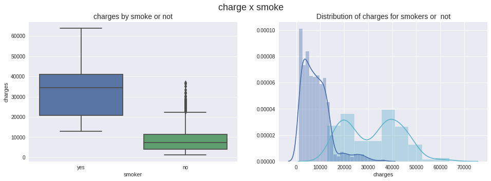

```python
fig, (ax1, ax2) = plt.subplots(figsize = (16,5), ncols=2, sharex=False, sharey=False)

font_size = 14
fig.suptitle('charge x smoke', fontsize=18)

sns.boxplot(x="smoker", y="charges", data=df, ax=ax1)
sns.distplot(df[(df.smoker == 'yes')]["charges"],color='c',ax=ax2, label='smoke')
sns.distplot(df[(df.smoker == 'no')]['charges'],color='b',ax=ax2, label='not smoke')

ax1.set_title('charges by smoke or not', fontsize=font_size)
ax2.set_title('Distribution of charges for smokers or  not', fontsize=font_size)
plt.show()
```

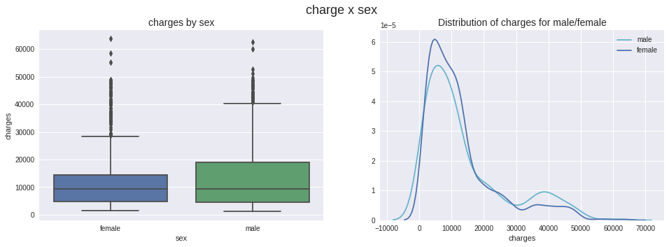

```python
fig, (ax1, ax2) = plt.subplots(figsize = (16,5), ncols=2, sharex=False, sharey=False)

font_size = 14
fig.suptitle('charge x sex', fontsize=18)

sns.boxplot(x="sex", y="charges", data=df, ax=ax1)
sns.distplot(df[(df.sex == 'male')]["charges"],color='c',ax=ax2, hist=False, label='male')
sns.distplot(df[(df.sex == 'female')]['charges'],color='b',ax=ax2, hist=False, label='female')

ax1.set_title('charges by sex', fontsize=font_size)
ax2.set_title('Distribution of charges for male/female', fontsize=font_size)

plt.show()
```

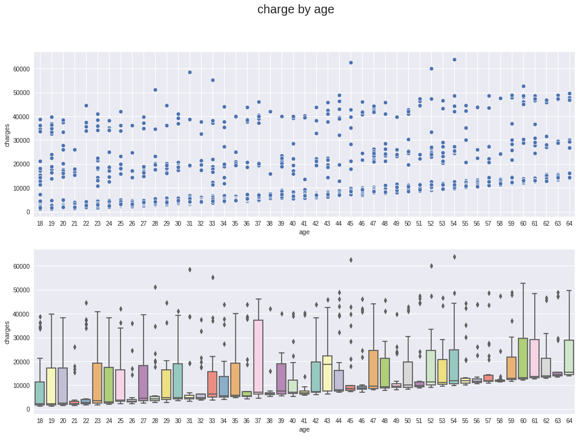

```python
fig, (ax1, ax2) = plt.subplots(figsize = (16,11), nrows=2)

sns.scatterplot(x="age", y="charges", data=df, ax=ax1)
sns.boxplot(x="age", y="charges", data=df, palette="Set3", ax=ax2)

# config scatterplot x_axis
ax1.set_xticks(range(18,65)) # show age axis
ax1.set_xlim(17.5,64.5) # remove right/left margin

# Config Titles
fig.suptitle('charge by age', fontsize=20)
plt.show()
```

### charges by bmi

[figure not shown]

```python
# Feature Engineering: Create 'weight_condition' to see better see bmi importance

df["weight_condition"] = np.nan
lst = [df]

for col in lst:
    col.loc[col["bmi"] < 18.5, "weight_condition"] = "Underweight"
    col.loc[(col["bmi"] >= 18.5) & (col["bmi"] < 24.986), "weight_condition"] = "Normal Weight"
    col.loc[(col["bmi"] >= 25) & (col["bmi"] < 29.926), "weight_condition"] = "Overweight"
    col.loc[col["bmi"] >= 30, "weight_condition"] = "Obese"
```

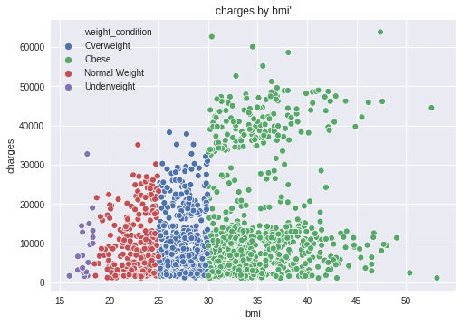

```python
ax = sns.scatterplot(x="bmi", y="charges", hue="weight_condition", data=df)
ax.set_title("charges by bmi'")
plt.show()
```

### Analyze feature crossover Go to TOC

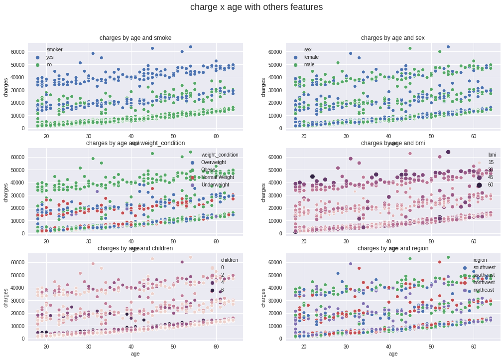

```python
fig, ((ax1, ax2), (ax3, ax4), (ax5, ax6)) = plt.subplots(figsize = (17,11), ncols=2, nrows=3, sharex=False, sharey=False)

sns.scatterplot(x="age", y="charges", hue="smoker", data=df, ax=ax1)
sns.scatterplot(x="age", y="charges", hue="sex", data=df, ax=ax2)
sns.scatterplot(x="age", y="charges", hue="weight_condition", data=df, ax=ax3)
sns.scatterplot(x="age", y="charges", hue="bmi", data=df, size="bmi", ax=ax4)

sns.scatterplot(x="age", y="charges", hue="children", data=df, ax=ax5)
sns.scatterplot(x="age", y="charges", hue="region", data=df, ax=ax6)

# Config Titles
fig.suptitle('charge x age with others features', fontsize=18)
ax1.set_title("charges by age and smoke")
ax2.set_title("charges by age and sex")
ax3.set_title("charges by age and weight_condition")
ax4.set_title("charges by age and bmi")
ax5.set_title("charges by age and children")
ax6.set_title("charges by age and region")
plt.show()
```

```python
# Feature Engineering: Create 'weight_condition' to see better 'age' importance

df['age_cat'] = np.nan
lst = [df]

for col in lst:
    col.loc[(col['age'] >= 18) & (col['age'] <= 30), 'age_cat'] = 'Young Adult'
    col.loc[(col['age'] >  30) & (col['age'] <= 50), 'age_cat'] = 'Adult'
    col.loc[(col['age'] >  50) & (col['age'] <= 60), 'age_cat'] = 'Senior'
    col.loc[ col['age'] >  60, 'age_cat'] = 'Elder'

df.head()
```

|  | age | sex | bmi | children | smoker | region | charges | weight_condition | age_cat |
| --- | --- | --- | --- | --- | --- | --- | --- | --- | --- |
| 0 | 19 | female | 27.900 | 0 | yes | southwest | 16,884.924 | Overweight | Young Adult |
| 1 | 18 | male | 33.770 | 1 | no | southeast | 1,725.552 | Obese | Young Adult |
| 2 | 28 | male | 33.000 | 3 | no | southeast | 4,449.462 | Obese | Young Adult |
| 3 | 33 | male | 22.705 | 0 | no | northwest | 21,984.471 | Normal Weight | Adult |
| 4 | 32 | male | 28.880 | 0 | no | northwest | 3,866.855 | Overweight | Adult |

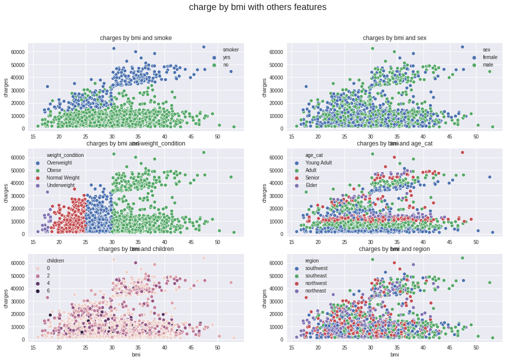

```python
fig, ((ax1, ax2), (ax3, ax4), (ax5, ax6)) = plt.subplots(figsize = (17,11), ncols=2, nrows=3, sharex=False, sharey=False)

sns.scatterplot(x="bmi", y="charges", hue="smoker", data=df, ax=ax1)
sns.scatterplot(x="bmi", y="charges", hue="sex", data=df, ax=ax2)

sns.scatterplot(x="bmi", y="charges", hue="weight_condition", data=df, ax=ax3)
sns.scatterplot(x="bmi", y="charges", hue="age_cat", data=df, ax=ax4)

sns.scatterplot(x="bmi", y="charges", hue="children", data=df, ax=ax5)
sns.scatterplot(x="bmi", y="charges", hue="region", data=df, ax=ax6)

# Config Titles
fig.suptitle('charge by bmi with others features', fontsize=18)
ax1.set_title("charges by bmi and smoke")
ax2.set_title("charges by bmi and sex")
ax3.set_title("charges by bmi and weight_condition")
ax4.set_title("charges by bmi and age_cat")
ax5.set_title("charges by bmi and children")
ax6.set_title("charges by bmi and region")

plt.show()
```

### Conclusions Of EDA Go to TOC

==> chart: 'charge' x 'smoke'

As in 'charge x smoke' the fact that smoking is very important, the distribution of cartoons is clearly different between a smoker and a non-smoker. Most smokers have much higher charges than non-smokers

==> chart: charge by age

The higher the age the higher the price

==> chart: cartoons by bmi

The larger the bmi, the greater the tendency to have large values, although only bmi does not explain large costs

==> chart: charge x age with others features

In 'cartoons by age and smoke' you can clearly perceive 3 classes.

- class 1, lower costs, are non-smokers
- class 2, average expenses, smokers and non-smokers
- class 3, higher expenses, smokers After looking at 'cartoons by age and weight_condition' we have that in the vast majority this third class is of obese people (high bmi)

==> chart: 'cartoons by bmi with others features'

In 'cartoons by bmi and age_cat' he shows us the missing piece, together with 'cartoons by bmi and smoke'.

Only by looking at the data of the mental activity, in which a decision tree is smoke, age and bmi.

1. If you smoke you will have more expenses than non-smokers (a good part of the population), expenses over 15,000
   - The BMI is analyzed, if not obese, it is in a group between 18,000 and 30,000, if obese over 35,000
   - For each of these two groups, the older you are, the more expensive it becomes
2. If you don't smoke expenses below 15,000
   - For non-fulmenates the second criterion would be age, the older the higher the expenditure
   - In this, bmi does not influence much. Despite this, some with normal weight or above (NormalWeight, Overweight or Obese) can fall in the cost of being as expensive as a smoker, mainly obese

==> Other features

gender, children and region have very little influence, this will also be seen in the correlations

## Pre-Processing Go to TOC

```python
# Before
df.head()
```

|  | age | sex | bmi | children | smoker | region | charges | weight_condition | age_cat |
| --- | --- | --- | --- | --- | --- | --- | --- | --- | --- |
| 0 | 19 | female | 27.900 | 0 | yes | southwest | 16,884.924 | Overweight | Young Adult |
| 1 | 18 | male | 33.770 | 1 | no | southeast | 1,725.552 | Obese | Young Adult |
| 2 | 28 | male | 33.000 | 3 | no | southeast | 4,449.462 | Obese | Young Adult |
| 3 | 33 | male | 22.705 | 0 | no | northwest | 21,984.471 | Normal Weight | Adult |
| 4 | 32 | male | 28.880 | 0 | no | northwest | 3,866.855 | Overweight | Adult |

```python
from sklearn.preprocessing import LabelEncoder

df = df.drop(['weight_condition','age_cat'], axis=1)

# sex
le = LabelEncoder()
le.fit(df.sex.drop_duplicates())
df.sex = le.transform(df.sex)

# smoker or not
le.fit(df.smoker.drop_duplicates())
df.smoker = le.transform(df.smoker)

# region
le.fit(df.region.drop_duplicates())
df.region = le.transform(df.region)

df.head() # after pre-processing
```

|  | age | sex | bmi | children | smoker | region | charges |
| --- | --- | --- | --- | --- | --- | --- | --- |
| 0 | 19 | 0 | 27.900 | 0 | 1 | 3 | 16,884.924 |
| 1 | 18 | 1 | 33.770 | 1 | 0 | 2 | 1,725.552 |
| 2 | 28 | 1 | 33.000 | 3 | 0 | 2 | 4,449.462 |
| 3 | 33 | 1 | 22.705 | 0 | 0 | 1 | 21,984.471 |
| 4 | 32 | 1 | 28.880 | 0 | 0 | 1 | 3,866.855 |

## Correlation Go to TOC

Numerical correlations with heatmap

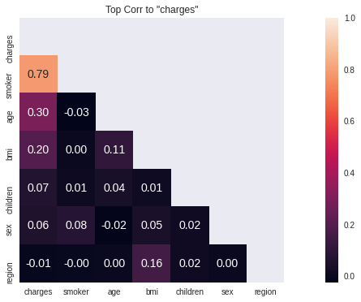

```python
corr_matrix = df.corr()
f, ax1 = plt.subplots(figsize=(18, 6), sharex=False)

ax1.set_title('Top Corr to {}'.format('"charges"'))
cols_top = corr_matrix.sort_values(by="charges", ascending=False)['charges'].index

cm = np.corrcoef(df[cols_top].values.T)
mask = np.zeros_like(cm)
mask[np.triu_indices_from(mask)] = True
hm = sns.heatmap(cm, cbar=True, annot=True, square=True, fmt='.2f',
                 annot_kws={'size': 14}, yticklabels=cols_top.values,
                 xticklabels=cols_top.values, mask=mask, ax=ax1)
```

What makes medical costs more expensive are: smoking, age and bmi

ANOVA: to categorical features

```python
# https://www.kaggle.com/hamelg/python-for-data-26-anova

import scipy.stats as stats
import statsmodels.api as sm
from statsmodels.formula.api import ols

def anova_analysis(y_target, x_cat_feats, datf):
    for x_feat in x_cat_feats:
        model = ols('{} ~ {}'.format(y_target, x_feat),
                    data = datf).fit()
        anova_result = sm.stats.anova_lm(model, typ=2)
        print(anova_result,'\n')


# If PR(>F) is less than 0.05 (alpha = cofiant level) means that the categorical feauture influence 'charges'
anova_analysis('charges', ['smoker', 'region'], df)
```

```
                      sum_sq        df         F  PR(>F)
smoker   121,519,903,621.667     1.000 2,177.615   0.000
Residual  74,554,317,946.700 1,336.000       nan     nan

                      sum_sq        df     F  PR(>F)
region         7,557,128.077     1.000 0.051   0.821
Residual 196,066,664,440.291 1,336.000   nan     nan
```

So smoking is really an important factor

## Split in Train and Test Go to TOC

```python
from sklearn.model_selection import train_test_split
from sklearn.preprocessing import PolynomialFeatures

# # Normal Split
# x = df.drop(['charges'], axis = 1)
# y = df['charges']
# x_train,x_test,y_train,y_test = train_test_split(x,y, random_state = 42)

####### OBS: IS better use Polinomal Transform than only split ############

# # Polinomial REgression: Feature Transform :
#   create x^0, x^1, x^2 .... to linear models to be polinomial

X = df.drop(['charges','region'], axis = 1)
Y = df.charges

quad = PolynomialFeatures(degree = 2)
x_quad = quad.fit_transform(X)

x_train,x_test,y_train,y_test = train_test_split(x_quad, Y, random_state = 0)
```

## Develop Models Go to TOC

Prepare ML Models and training

```python
from sklearn.model_selection import GridSearchCV, KFold, cross_val_score, train_test_split
from sklearn.neural_network import MLPRegressor
from sklearn.preprocessing import OneHotEncoder, LabelEncoder, StandardScaler, RobustScaler, scale
from sklearn.decomposition import PCA
from sklearn.linear_model import ElasticNet, LassoCV, BayesianRidge, LassoLarsIC
from sklearn.linear_model import Ridge, RidgeCV, ElasticNet, ElasticNetCV, LinearRegression
from sklearn.kernel_ridge import KernelRidge
from mlxtend.regressor import StackingCVRegressor
from sklearn.pipeline import make_pipeline
from sklearn.ensemble import RandomForestRegressor, GradientBoostingRegressor, ExtraTreesRegressor
from sklearn.ensemble import AdaBoostRegressor, BaggingRegressor
from sklearn.metrics import mean_squared_error, r2_score
from sklearn.base import BaseEstimator, TransformerMixin, RegressorMixin, clone
from sklearn.svm import SVR

from lightgbm import LGBMRegressor
from xgboost import XGBRegressor
```

```python
# Setup cross validation folds

kf = KFold(n_splits=4, random_state=42, shuffle=True)

# Define error metrics
def rmse(y, y_pred):
    return np.sqrt(mean_squared_error(y, y_pred))

def cv_rmse(model, X=x_train):
    rmse = np.sqrt(-cross_val_score(model, X, y_train, scoring="neg_mean_squared_error", cv=kf))
    return (rmse)
```

```python
# Create ML Models

# Light Gradient Boosting Regressor
lightgb_model = LGBMRegressor(objective='regression',  num_leaves=6, learning_rate=0.01,  n_estimators=7000,
                       max_bin=200,  bagging_fraction=0.8, bagging_freq=4,  bagging_seed=8,
                       feature_fraction=0.2, feature_fraction_seed=8, min_sum_hessian_in_leaf = 11,
                       verbose=-1, random_state=42)

# XGBoost Regressor
xgboost_model = XGBRegressor(learning_rate=0.01, n_estimators=6000, max_depth=4, min_child_weight=0,
                       gamma=0.6, subsample=0.7, colsample_bytree=0.7, objective='reg:squarederror',
                       nthread=-1, scale_pos_weight=1, seed=42, reg_alpha=0.00006, random_state=42)

# Linear Regressor
linear_model = LinearRegression()

# Ridge Regressor
ridge_alphas = [1e-15, 1e-10, 1e-8, 9e-4, 7e-4, 5e-4, 3e-4, 1e-4,
                1e-3, 5e-2, 1e-2, 0.1, 0.3, 1, 3, 5, 10, 15, 18, 20, 30, 50, 75, 100]
ridge_model = make_pipeline(RobustScaler(), RidgeCV(alphas=ridge_alphas, cv=kf))

# Lasso Regressor
lasso_alphas2 = [5e-05, 0.0001, 0.0008, 0.01, 0.1, 1]
lasso_model = make_pipeline(RobustScaler(),
                      LassoCV(max_iter=1e7, alphas=lasso_alphas2,
                              random_state=42, cv=kf))

# Elastic Net Regressor
elastic_alphas = [0.0001, 0.0002, 0.0003, 0.0004, 0.0005, 0.0006, 0.0007]
elastic_l1ratio = [0.8, 0.85, 0.9, 0.95, 0.99, 1]
elasticnet_model = make_pipeline(RobustScaler(),
                           ElasticNetCV(max_iter=1e7, alphas=elastic_alphas,
                                        cv=kf, l1_ratio=elastic_l1ratio))

# Kernel Ridge
keridge_model = KernelRidge(alpha=0.6, kernel='polynomial', degree=2, coef0=2.5)

# Support Vector Regressor
svm_model = make_pipeline(RobustScaler(), SVR(C= 20, epsilon= 0.008, gamma=0.0003))

# Gradient Boosting Regressor
gboost_model = GradientBoostingRegressor(n_estimators=6000, learning_rate=0.01, max_depth=4, max_features='sqrt',
                                min_samples_leaf=15, min_samples_split=10, loss='huber', random_state=42)

# Random Forest Regressor
randomforest_model = RandomForestRegressor(n_estimators=1200, max_depth=15, min_samples_split=5, min_samples_leaf=5,
                          max_features=None, oob_score=True, random_state=42)

# Neural Net
neuralnet_model = MLPRegressor()

# Extra Tree Regressor
extratree_model = ExtraTreesRegressor()
```

```python
# SVM and NeuralNet was completally terrible

regressor_models = {
    'Linear': linear_model,
    'Ridge': ridge_model,
    'Lasso': lasso_model,
    'KernelRidge': keridge_model,
    'ElasticNet': elasticnet_model,
#     'SVM': svm_model,
    'RandomForest': randomforest_model,
    'ExtraTree': extratree_model,
#     'NeuralNet': neuralnet_model,
    'GBoost': gboost_model,
    'LightGB': lightgb_model,
    'XGBoost': xgboost_model,
}
```

### Cross Validation Go to TOC

```python
## Cross Validation

cv_scores = {}
t_start = time.time()

for model_name, model in regressor_models.items():
    print('{:17}'.format(model_name), end='')
    t0 = time.time()
    score = cv_rmse(model)
    m, s = score.mean(), score.std()
    cv_scores[model_name] = [m,s]
    print('| MSE in CV | mean: {:11,.3f}, | std: {:9,.3f}  | took: {:9,.3f} s |'.format(m,s, time.time() - t0))

print('\nTime total to CrossValidation: took {:9,.3f} s'.format(time.time() - t_start)) # 200s

# Show Sorted DataFrame
df_cv = pd.DataFrame(data = cv_scores.values(), columns=['rmse_cv', 'std_cv'], index=cv_scores.keys())
df_cv = df_cv.sort_values(by='rmse_cv').reset_index().rename({'index': 'model'}, axis=1)
df_cv
```

```
Linear           | MSE in CV | mean:   5,050.271, | std:   517.483  | took:     0.033 s |
Ridge            | MSE in CV | mean:   5,052.135, | std:   516.345  | took:     1.101 s |
Lasso            | MSE in CV | mean:   5,048.281, | std:   517.048  | took:     0.287 s |
KernelRidge      | MSE in CV | mean:   5,328.054, | std:   482.644  | took:     0.122 s |
ElasticNet       | MSE in CV | mean:   5,049.433, | std:   517.411  | took:    70.289 s |
RandomForest     | MSE in CV | mean:   4,904.850, | std:   437.848  | took:    26.085 s |
ExtraTree        | MSE in CV | mean:   5,807.069, | std:   464.081  | took:     1.602 s |
GBoost           | MSE in CV | mean:   4,753.254, | std:   475.499  | took:    72.631 s |
LightGB          | MSE in CV | mean:   5,265.818, | std:   474.002  | took:     6.951 s |
XGBoost          | MSE in CV | mean:   5,368.779, | std:   448.594  | took:    23.067 s |

Time total to CrossValidation: took   202.170 s
```

|  | model | rmse_cv | std_cv |
| --- | --- | --- | --- |
| 0 | GBoost | 4,753.254 | 475.499 |
| 1 | RandomForest | 4,904.850 | 437.848 |
| 2 | Lasso | 5,048.281 | 517.048 |
| 3 | ElasticNet | 5,049.433 | 517.411 |
| 4 | Linear | 5,050.271 | 517.483 |
| 5 | Ridge | 5,052.135 | 516.345 |
| 6 | LightGB | 5,265.818 | 474.002 |
| 7 | KernelRidge | 5,328.054 | 482.644 |
| 8 | XGBoost | 5,368.779 | 448.594 |
| 9 | ExtraTree | 5,807.069 | 464.081 |

## Fit Models Go to TOC

```python
# Def Stack Model: Stack up some the models above, optimized using one ml model
stack_regressors = (regressor_models['Lasso'],
                    regressor_models['LightGB'],
                    regressor_models['Ridge'],
                    regressor_models['RandomForest'])

stack_model = StackingCVRegressor(regressors = stack_regressors,
                                meta_regressor = regressor_models['ElasticNet'],
                                use_features_in_secondary=True)

regressor_models['Stack'] = stack_model
```

```python
train_scores = {}
t_start = time.time()

for model_name, model in regressor_models.items():
    print('{:17}'.format(model_name), end='')
    t0 = time.time()
    if(model_name == 'Stack'):
        model  = model.fit(np.array(x_train), np.array(y_train))
        y_pred = model.predict(np.array(x_train))
    else:
        model  = model.fit( x_train, y_train )
        y_pred = model.predict(x_train)
    r2, mse = r2_score(y_train, y_pred), mean_squared_error(y_train, y_pred)
    train_scores[model_name] = [r2, mse, np.sqrt(mse)]
    text_print = '| Train | r2: {:6,.3f}, | mse: {:15,.3f}  | took: {:9,.3f} s |'
    print(text_print.format(r2, mse, time.time() - t0))
    regressor_models[model_name] = model

print('\nTime total to Fit Models: took {:9,.3f} s'.format(time.time() - t_start)) # 200s
```

```
Linear           | Train | r2:  0.828, | mse:  24,581,739.662  | took:     0.005 s |
Ridge            | Train | r2:  0.828, | mse:  24,584,542.683  | took:     0.299 s |
Lasso            | Train | r2:  0.828, | mse:  24,583,886.521  | took:     0.073 s |
KernelRidge      | Train | r2:  0.842, | mse:  22,645,908.417  | took:     0.049 s |
ElasticNet       | Train | r2:  0.828, | mse:  24,582,387.372  | took:    18.040 s |
RandomForest     | Train | r2:  0.903, | mse:  13,928,745.032  | took:     7.928 s |
ExtraTree        | Train | r2:  0.999, | mse:      77,906.488  | took:     0.479 s |
GBoost           | Train | r2:  0.861, | mse:  19,861,089.397  | took:    20.135 s |
LightGB          | Train | r2:  0.928, | mse:  10,346,399.081  | took:     2.317 s |
XGBoost          | Train | r2:  0.993, | mse:     984,675.283  | took:     7.741 s |
Stack            | Train | r2:  0.874, | mse:  18,027,198.050  | took:   172.704 s |

Time total to Fit Models: took   229.772 s
```

```python
regressor_models.keys()
```

```
dict_keys(['Linear', 'Ridge', 'Lasso', 'KernelRidge', 'ElasticNet', 'RandomForest', 'ExtraTree', 'GBoost', 'LightGB', 'XGBoost', 'Stack'])
```

```python
# Blend Model is use a porcentage of some models mixing
class BlendModel:

    @classmethod
    def predict(self, X):
        return ((0.10 * regressor_models['Lasso'].predict(X)) + \
            (0.10 * regressor_models['GBoost'].predict(X)) + \
            (0.15 * regressor_models['XGBoost'].predict(X)) + \
            (0.10 * regressor_models['LightGB'].predict(X)) + \
            (0.20 * regressor_models['RandomForest'].predict(X)) + \
            (0.35 * regressor_models['Stack'].predict(np.array(X))))

regressor_models['BlendModel'] = BlendModel()
y_pred = BlendModel.predict(x_train)
r2, mse = r2_score(y_train, y_pred), mean_squared_error(y_train, y_pred)
train_scores['BlendModel'] = [r2, mse, np.sqrt(mse)]
print('RMSE score on train data to Blend Model:\n\t=>', np.sqrt(mse))
```

```
RMSE score on train data to Blend Model:
	=> 3505.7637905903
```

```python
from mlens.ensemble import SuperLearner

# create a list of base-models
def get_models_to_super_leaner():
    models = list()
    models.append(regressor_models['Linear'])
    models.append(regressor_models['Ridge'])
    models.append(regressor_models['Lasso'])
    models.append(regressor_models['KernelRidge'])
    models.append(regressor_models['ElasticNet'])
    models.append(regressor_models['RandomForest'])
    models.append(regressor_models['GBoost'])
    return models

# create the super learner
def get_super_learner(X):
    ensemble = SuperLearner(scorer=rmse, folds=5, shuffle=True, sample_size=len(X))
    # add base models
    models = get_models_to_super_leaner()
    ensemble.add(models)
    # add the meta model
    ensemble.add_meta(LinearRegression())
    return ensemble

# key to regressros models
model_name = 'SuperLeaner'

# create the super learner
ensemble = get_super_learner(x_train)
# fit the super learner
t0 = time.time()
ensemble.fit(x_train, np.array(y_train)) # took 350s = 6min
# pred and evaluate in train dataset
y_pred = ensemble.predict(x_train)
r2, mse = r2_score(y_train, y_pred), mean_squared_error(y_train, y_pred)
train_scores[model_name] = [r2, mse, np.sqrt(mse)]
# show results
text_print = '| Super Leaner in Train | r2: {:6,.3f}, | mse: {:9,.3f}  | took: {:9,.3f} s |\n'
print(text_print.format(r2, mse, time.time() - t0))
# set in dict regressors
regressor_models[model_name] = ensemble
# summarize base learners
print(ensemble.data)
# evaluate meta model
```

```
[MLENS] backend: threading
```

```
| Super Leaner in Train | r2:  0.866, | mse: 19,210,411.435  | took:   279.629 s |

                                      score-m  score-s    ft-m   ft-s  pt-m  pt-s
layer-1  gradientboostingregressor    4752.97   625.97  119.88  41.72  0.04  0.00
layer-1  kernelridge                  5282.52   444.67    0.03   0.00  0.01  0.00
layer-1  linearregression             5046.46   533.28    0.01   0.00  0.00  0.00
layer-1  pipeline-1                   5051.80   530.77    0.75   0.02  0.00  0.00
layer-1  pipeline-2                   5043.13   531.15    0.23   0.03  0.00  0.00
layer-1  pipeline-3                   5045.72   533.08   38.18   3.34  0.01  0.01
layer-1  randomforestregressor        4804.33   570.85   18.16   2.73  0.45  0.13
```

```python
# Show train_scores dataframe
df_train_scores = pd.DataFrame(data = train_scores.values(),index=train_scores.keys(), columns=['r2_train', 'mse_train', 'rmse_train'])
df_train_scores = df_train_scores.sort_values(by='r2_train', ascending=False).reset_index().rename({'index': 'model'}, axis=1)
df_train_scores
```

|  | model | r2_train | mse_train | rmse_train |
| --- | --- | --- | --- | --- |
| 0 | ExtraTree | 0.999 | 77,906.488 | 279.117 |
| 1 | XGBoost | 0.993 | 984,675.283 | 992.308 |
| 2 | LightGB | 0.928 | 10,346,399.081 | 3,216.582 |
| 3 | BlendModel | 0.914 | 12,290,379.755 | 3,505.764 |
| 4 | RandomForest | 0.903 | 13,928,745.032 | 3,732.123 |
| 5 | Stack | 0.874 | 18,027,198.050 | 4,245.845 |
| 6 | SuperLeaner | 0.866 | 19,210,411.435 | 4,382.968 |
| 7 | GBoost | 0.861 | 19,861,089.397 | 4,456.578 |
| 8 | KernelRidge | 0.842 | 22,645,908.417 | 4,758.772 |
| 9 | Linear | 0.828 | 24,581,739.662 | 4,957.998 |
| 10 | ElasticNet | 0.828 | 24,582,387.372 | 4,958.063 |
| 11 | Lasso | 0.828 | 24,583,886.521 | 4,958.214 |
| 12 | Ridge | 0.828 | 24,584,542.683 | 4,958.280 |

## Test Models Go to TOC

```python
test_scores = {}

# predcit x_test to y_test and compare
for model_name, model in regressor_models.items():
    if(model_name == 'Stack'):
        y_pred = model.predict(np.array(x_test))
    else:
        y_pred = model.predict(x_test)
    r2, mse = r2_score(y_test, y_pred), mean_squared_error(y_test, y_pred)
    test_scores[model_name] = [r2, mse, np.sqrt(mse)]

# Sort DF test scores
df_test_scores = pd.DataFrame(data = test_scores.values(), columns=['r2_test', 'mse_test', 'rmse_test'], index=test_scores.keys())
df_test_scores = df_test_scores.sort_values(by='r2_test', ascending=False).reset_index().rename({'index': 'model'}, axis=1)
df_test_scores
```

|  | model | r2_test | mse_test | rmse_test |
| --- | --- | --- | --- | --- |
| 0 | SuperLeaner | 0.908 | 14,542,326.460 | 3,813.440 |
| 1 | GBoost | 0.904 | 15,077,543.508 | 3,882.981 |
| 2 | BlendModel | 0.898 | 16,110,720.369 | 4,013.816 |
| 3 | RandomForest | 0.894 | 16,731,114.456 | 4,090.368 |
| 4 | Stack | 0.893 | 16,787,147.437 | 4,097.212 |
| 5 | Linear | 0.885 | 18,117,605.544 | 4,256.478 |
| 6 | ElasticNet | 0.885 | 18,136,127.229 | 4,258.653 |
| 7 | Lasso | 0.885 | 18,146,677.085 | 4,259.892 |
| 8 | Ridge | 0.885 | 18,157,209.758 | 4,261.128 |
| 9 | LightGB | 0.882 | 18,586,883.844 | 4,311.251 |
| 10 | KernelRidge | 0.882 | 18,589,131.486 | 4,311.512 |
| 11 | XGBoost | 0.860 | 21,969,580.440 | 4,687.172 |
| 12 | ExtraTree | 0.853 | 23,107,470.209 | 4,807.023 |

## Best Models Go to TOC

```python
# Include Blend in Train Scores
df_train_scores = pd.DataFrame(data = train_scores.values(),index=train_scores.keys(), columns=['r2_train', 'mse_train', 'rmse_train'])
df_train_scores = df_train_scores.sort_values(by='r2_train', ascending=False).reset_index().rename({'index': 'model'}, axis=1)

# df_test_scores
df_cv2 = df_cv.merge(df_train_scores, how='right'  ,left_on='model', right_on='model')
df_final_scores = df_cv2.merge(df_test_scores, how='right' ,left_on='model', right_on='model')

print(list(df_final_scores.columns))
df_final_scores.sort_values(by='mse_test')
```

```
['model', 'rmse_cv', 'std_cv', 'r2_train', 'mse_train', 'rmse_train', 'r2_test', 'mse_test', 'rmse_test']
```

|  | model | rmse_cv | std_cv | r2_train | mse_train | rmse_train | r2_test | mse_test | rmse_test |
| --- | --- | --- | --- | --- | --- | --- | --- | --- | --- |
| 0 | SuperLeaner | nan | nan | 0.866 | 19,210,411.435 | 4,382.968 | 0.908 | 14,542,326.460 | 3,813.440 |
| 1 | GBoost | 4,753.254 | 475.499 | 0.861 | 19,861,089.397 | 4,456.578 | 0.904 | 15,077,543.508 | 3,882.981 |
| 2 | BlendModel | nan | nan | 0.914 | 12,290,379.755 | 3,505.764 | 0.898 | 16,110,720.369 | 4,013.816 |
| 3 | RandomForest | 4,904.850 | 437.848 | 0.903 | 13,928,745.032 | 3,732.123 | 0.894 | 16,731,114.456 | 4,090.368 |
| 4 | Stack | nan | nan | 0.874 | 18,027,198.050 | 4,245.845 | 0.893 | 16,787,147.437 | 4,097.212 |
| 5 | Linear | 5,050.271 | 517.483 | 0.828 | 24,581,739.662 | 4,957.998 | 0.885 | 18,117,605.544 | 4,256.478 |
| 6 | ElasticNet | 5,049.433 | 517.411 | 0.828 | 24,582,387.372 | 4,958.063 | 0.885 | 18,136,127.229 | 4,258.653 |
| 7 | Lasso | 5,048.281 | 517.048 | 0.828 | 24,583,886.521 | 4,958.214 | 0.885 | 18,146,677.085 | 4,259.892 |
| 8 | Ridge | 5,052.135 | 516.345 | 0.828 | 24,584,542.683 | 4,958.280 | 0.885 | 18,157,209.758 | 4,261.128 |
| 9 | LightGB | 5,265.818 | 474.002 | 0.928 | 10,346,399.081 | 3,216.582 | 0.882 | 18,586,883.844 | 4,311.251 |
| 10 | KernelRidge | 5,328.054 | 482.644 | 0.842 | 22,645,908.417 | 4,758.772 | 0.882 | 18,589,131.486 | 4,311.512 |
| 11 | XGBoost | 5,368.779 | 448.594 | 0.993 | 984,675.283 | 992.308 | 0.860 | 21,969,580.440 | 4,687.172 |
| 12 | ExtraTree | 5,807.069 | 464.081 | 0.999 | 77,906.488 | 279.117 | 0.853 | 23,107,470.209 | 4,807.023 |

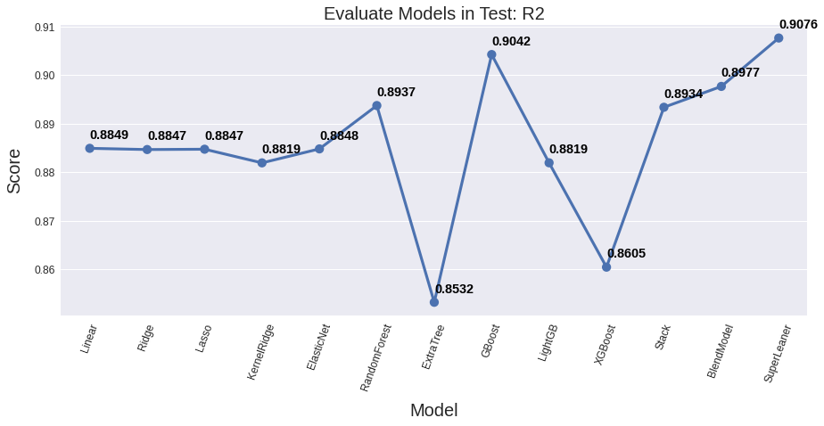

```python
plot_model_score_regression(list(test_scores.keys()), [r2 for r2, mse, rmse in test_scores.values()], 'Evaluate Models in Test: R2')
```

Unfortunately, there is no (or do not know how) to do cross validation for SuperLeaner. Since your score on the training and test data is similar to that of GBoost we can assume your score for cross validation, it would be similar to that of GBoost.

It happened that in the training data some models were overfitted, such as ExtraTree, XGBoost and LightGB. You can see this by observing that they were almost perfect in the training data but failed like any other model in the test data.

Even though some models cannot do corss validation (Blend, Stack, SuperLeaner) when ordering by 'mse_test' we realize that the models that can make cv are in the same position if you compare 'mse_test' with 'rmse_cv'. So Blend and Stack were also good models, too.

## Feature Importance Go to TOC

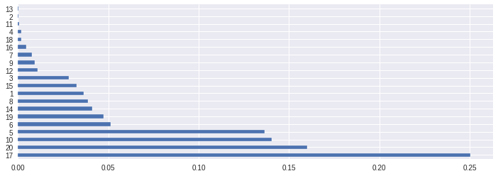

```python
# To one of best models: GBoost

plt.figure(figsize = (12,4))
feat_importances = pd.Series(regressor_models['GBoost'].feature_importances_)#, index=X.columns)
feat_importances.nlargest(20).plot(kind='barh')
plt.show()
```

```
Time total to RFECV to Linear : took     1.679 s
```

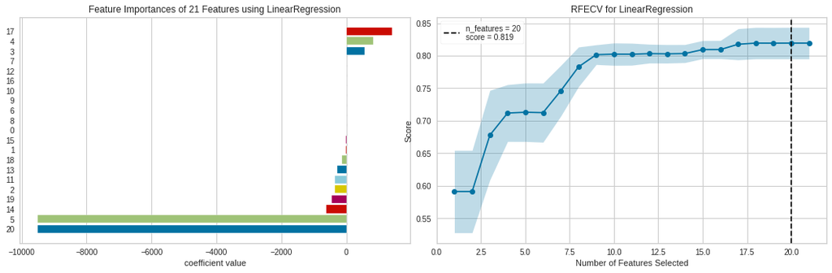

```python
from yellowbrick.model_selection import FeatureImportances, RFECV

# FeatureImportances and RFECV to a good model, if put GBoost(the best) take a long time

fig, (ax3,ax4) = plt.subplots(figsize = (15,5), ncols=2, sharex=False, sharey=False)

the_model = 'Linear'
t_start = time.time()

viz3 = FeatureImportances(regressor_models[the_model], ax=ax3, relative=False)
viz3.fit(x_train, y_train)
viz3.finalize()

viz4 = RFECV(regressor_models[the_model], ax=ax4)
viz4.fit(x_train, y_train)
viz4.finalize()

print('Time total to RFECV to {} : took {:9,.3f} s'.format(the_model, time.time() - t_start))

plt.show()
```

### Evaluate Best Model to Regression Go to TOC

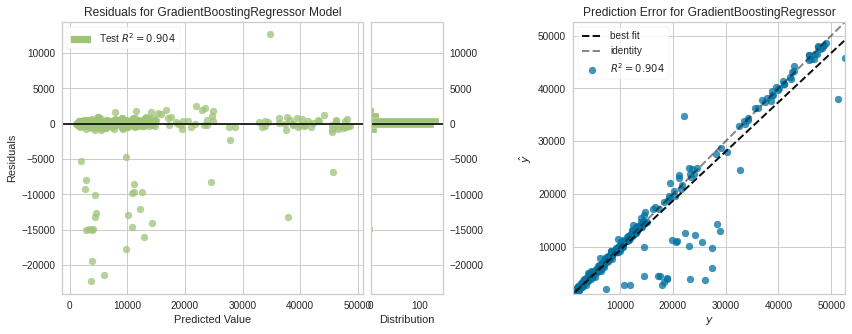

```python
from yellowbrick.regressor import ResidualsPlot, PredictionError
from yellowbrick.model_selection import FeatureImportances, RFECV

# Can't use 'SuperLeaner' than, use the second place: GBoost

fig, (ax1, ax2) = plt.subplots(figsize = (15,5), ncols=2)

viz1 = ResidualsPlot(regressor_models['GBoost'], ax=ax1)
viz1.score(x_test, y_test)
viz1.finalize()

viz2 = PredictionError(regressor_models['GBoost'], ax=ax2)
viz2.score(x_test, y_test)
viz2.finalize()

plt.show()
```

## Conclusion Go to TOC

The better model was: SuperLeaner with MSE

```python
from sklearn.metrics import mean_absolute_error, mean_squared_log_error

y_pred = regressor_models['SuperLeaner'].predict(x_test)
print('The best Regressor Model to Test DataSet:')
print('MAE : {:14,.3f}'.format(mean_absolute_error(y_pred, y_test)))
print('MSE : {:14,.3f}'.format(mean_squared_error(y_pred, y_test)))
print('RMSE: {:14,.3f}'.format(np.sqrt(mean_squared_error(y_pred, y_test))))
print('MSLE: {:14,.3f}'.format(mean_squared_log_error(y_pred, y_test)))
print('R2  : {:14,.3f}'.format(r2_score(y_pred, y_test)))
```

```
The best Regressor Model to Test DataSet:
MAE :      2,141.791
MSE : 14,542,326.460
RMSE:      3,813.440
MSLE:          0.139
R2  :          0.902
```

The better model was SuperLeaner with the results above.

This Kernel is still under development. I would highly appreciate your feedback for improvement and, of course, if you like it, please upvote it!

Please Upvote (It motivates me)